# MITx The Analytics Edge – Unit 6 Clustering – Segmenting Images

Flower.csv sisältää 50x50 kokoisen matriisin grayscale-arvoja väliltä 0-1.

```r
flower = read.csv("datasets/flower.csv", header=FALSE)
flowerMatrix = as.matrix(flower)
mean(flowerMatrix)
```

```
[1] 0.3326597
```

50x50 matriisi voidaan muuttaa 2500 solun kokoiseksi vektoriksi:

```r
flowerVector = as.vector(flowerMatrix)
length(flowerVector)
```

```
[1] 2500
```

Lasketaan etäisyysmatriisi ja tehdään hierarkinen klusterointi (vaikka en ymmärräkään yhtään että mitä tässä tapahtuu). Funktiolla “rect.hclust” piirretään punaiset laatikoit niiden klusterien ympärille jotka halutaan poistaa hierarkiasta ylimääräisinä.

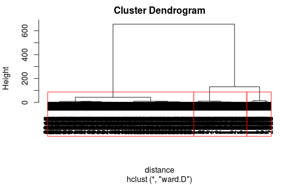

```r
distance = dist(flowerVector, method="euclidian")
clusterIntencity = hclust(distance, method="ward.D")
plot(clusterIntencity)
rect.hclust(clusterIntencity, k=3, border="red")
```

Parametrilla k=3 voidaan leikata tästä puusta pois kaikki ylimääräiset haarat näiden 3 haaran lisäksi. Kuten näkyy niin kaikki data on nyt luokiteltu näihin 3 klusteriin.

```r
flowerClusters = cutree(clusterIntencity, k=3)
table(flowerClusters)/length(flowerClusters)
```

```
flowerClusters
     1      2      3
0.6536 0.1088 0.2376
```

Piirretään grayscale-kuva ruudulle väritettynä sen pikseleille annettujen klusteriluokitusten perusteella:

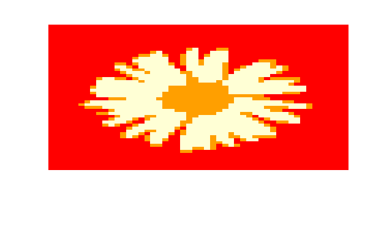

```r
dim(flowerClusters) = c(50,50)
image(flowerClusters, axes=FALSE)
```

Ladataan toinen datasetti joka sisältää MRI brain scan kuvan:

```r
healthy = read.csv("datasets/healthy.csv", header=FALSE)
healthyMatrix = as.matrix(healthy)
str(healthyMatrix)
```

```
 num [1:566, 1:646] 0.00427 0.00855 0.01282 0.01282 0.01282 ...
 - attr(*, "dimnames")=List of 2
  ..$ : NULL
  ..$ : chr [1:646] "V1" "V2" "V3" "V4" ...
```

Piirretään matriisi joka sisältää kuvan väriarvot ruudulle grayscale-paletilla väritettynä:

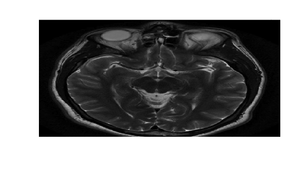

```r
image(healthyMatrix, axes=FALSE, col=gray(seq(0, 1, length=256)))
```

Dist-funktio joutuu laskemaan näin monta arvoa (66 miljardia) jos syötämme healthyVector sille parametriksi, siksi on parempi käyttää jotain muuta toimintatapaa:

```r
healthyVector = as.vector(healthyMatrix)
n=length(healthyVector)
n*(n-1)/2
```

```
[1] 66844659430
```

Hierarkisen klusteroinnin sijaan korkean resoluution kuvaa klusteroidessa täytyy käyttää K-Means klusterointia:

```r
set.seed(1)
k=5
KMC = kmeans(healthyVector, centers=k, iter.max=1000)
str(KMC)
```

```
List of 9
 $ cluster     : int [1:365636] 3 3 3 3 3 3 3 3 3 3 ...
 $ centers     : num [1:5, 1] 0.4818 0.1062 0.0196 0.3094 0.1842
  ..- attr(*, "dimnames")=List of 2
  .. ..$ : chr [1:5] "1" "2" "3" "4" ...
  .. ..$ : NULL
 $ totss       : num 5775
 $ withinss    : num [1:5] 96.6 47.2 39.2 57.5 62.3
 $ tot.withinss: num 303
 $ betweenss   : num 5472
 $ size        : int [1:5] 20556 101085 133162 31555 79278
 $ iter        : int 2
 $ ifault      : int 0
 - attr(*, "class")= chr "kmeans"
```

KMC$centers avulla voidaan tarkastella eri klustereille annettuja intensiteettiarvoja:

```r
healthyClusters = KMC$cluster
KMC$centers
```

```
        [,1]
1 0.48177191
2 0.10619450
3 0.01961886
4 0.30942825
5 0.18420578
```

Kun muutetaan healthyClusters matriisiksi, niin voimme visualisoida klusterit image-funktion avulla:

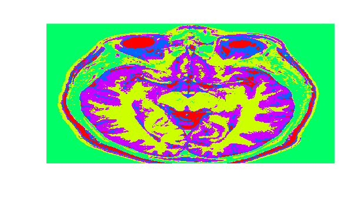

```r
dim(healthyClusters) = c(nrow(healthyMatrix), ncol(healthyMatrix))
image(healthyClusters, axes=FALSE, col=rainbow(k))
```

Ladataan uusi MRI-aivokuva jossa potilaalla tiedetään olevan aivokasvain. Flexclust-kirjaston kcca-funktio implementoi k-centroids cluster analysis -menetelmän.

```r
library(flexclust)
tumor = read.csv("datasets/tumor.csv", header=FALSE)
tumorMatrix = as.matrix(tumor)
tumorVector = as.vector(tumorMatrix)
KMC.kcca = as.kcca(KMC, healthyVector)
tumorClusters = predict(KMC.kcca, newdata=tumorVector)
```

Kcca-metodin tuottamat klusteridata voidaan muuttaa matriisiksi ja visualisoida image-funktion avulla. Jostain syystä kuva piirtyi vaakatasoon vaikka videoissa se piirtyi samalla koodilla pystytasoon (pieni virhe jossain?).

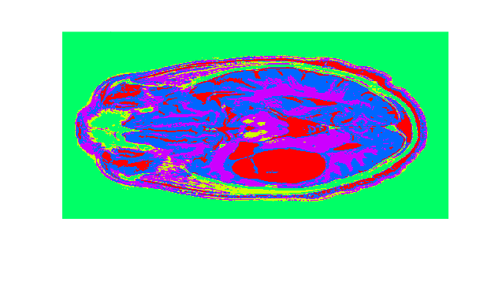

```r
dim(tumorClusters) = c(nrow(tumorMatrix), ncol(tumorMatrix))
image(tumorClusters, axes=FALSE, col=rainbow(k))
```